# Disaster Relief Project: Part I

Rehan Merchant rm2bt

Mar 29, 2021

**SYS 6018 | Spring 2021 | University of Virginia**

# 1 Introduction

In 2010 an earthquake hit Haiti and caused a lot of destruction in the country. Many of the residents of Haiti were displaced and cut off from food and water sources. Communication and roads were also effected by the earthquake. Because of this, officials had trouble locating displaced citizens and getting aid to them. In order to solve this problem, an aircraft was flown above to collect images of the ground. This would help identify shelters that have been created by displaced individuals. Because, this was time sensitive, the images were ran through data mining algorithms to search the images quickly and effectively in order to locate those displaced individuals. We are attempting to simulate what happened in 2010 by testing different models on the imagery collected from the disaster in 2010. After testing each of these models, we will compare and come up with which model would produce the most accurate results in a timely manner.

# 2 Training Data / EDA

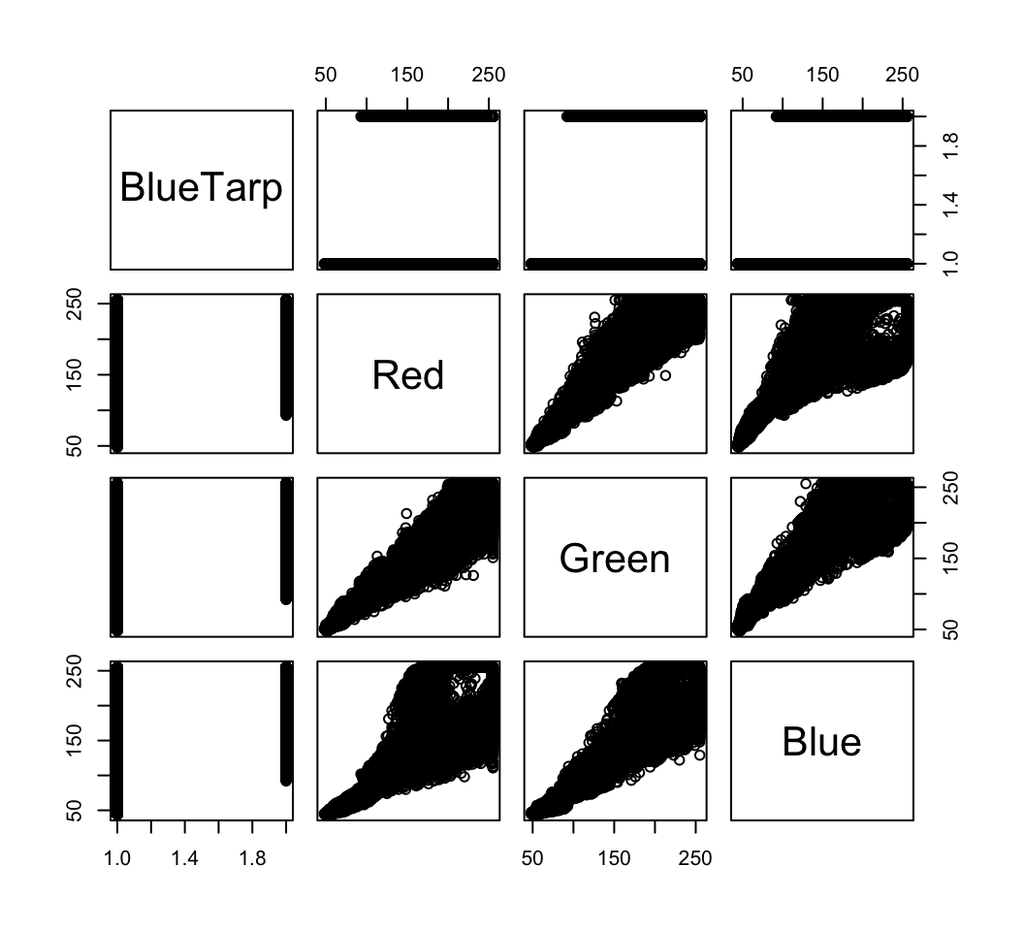

```r
# Load Required Packages
library(tidyverse)
library(caret)
library(MASS)
library(boot)
library(ggplot2)
library(dplyr)
library(stringr)
library(GGally)
library(ROCR)
library(MLeval)
library(pROC)
library(glmnet)
library(yardstick)
#load data
data <- read.csv('HaitiPixels.csv')
attach(data)
data$BlueTarp <- str_detect(Class,"Blue Tarp")
data$BlueTarp <- factor(data$BlueTarp)
pairs(BlueTarp~ Red + Green + Blue, data = data)
```

```r
#positive correlation between the variables but none between BlueTarp
#made blue tarp a separate variable and made it a binary 2 class variable
```

# 3 Model Training

## 3.1 Set-up

```r
set.seed(1)
index <- createDataPartition(y = data$BlueTarp, p =0.5, list = F)
train <- data[index,]
test <- data[-index,]
```

## 3.2 Logistic Regression

```r
glm.fits <- glm(BlueTarp ~ Red + Green + Blue, family = 'binomial', data = data)
summary(glm.fits)
```

```
#>
#> Call:
#> glm(formula = BlueTarp ~ Red + Green + Blue, family = "binomial",
#>     data = data)
#>
#> Deviance Residuals:
#>     Min       1Q   Median       3Q      Max
#> -3.4266  -0.0205  -0.0015   0.0000   3.7911
#>
#> Coefficients:
#>             Estimate Std. Error z value Pr(>|z|)
#> (Intercept)  0.20984    0.18455   1.137    0.256
#> Red         -0.26031    0.01262 -20.632   <2e-16 ***
#> Green       -0.21831    0.01330 -16.416   <2e-16 ***
#> Blue         0.47241    0.01548  30.511   <2e-16 ***
#> ---
#> Signif. codes:  0 '***' 0.001 '**' 0.01 '*' 0.05 '.' 0.1 ' ' 1
#>
#> (Dispersion parameter for binomial family taken to be 1)
#>
#>     Null deviance: 17901.6  on 63240  degrees of freedom
#> Residual deviance:  1769.5  on 63237  degrees of freedom
#> AIC: 1777.5
#>
#> Number of Fisher Scoring iterations: 12
```

```r
#all predictors are significant except intercept

#crossval
ctrl <- trainControl(method='cv',
                     number=10,
                     savePredictions = T)
glmmod <- train(BlueTarp~ .-Class,
                data=train,
                method='glm',
                trControl=ctrl)
glmmod$results
```

```
#>   parameter  Accuracy     Kappa  AccuracySD    KappaSD
#> 1      none 0.9951615 0.9181186 0.001273883 0.02250946
```

```r
#predict
glm.predict <- predict(glm.fits, newdata = test, type="response")

#confusionMatrix

confusionMatrix(data = as.factor(glm.predict>=0.5), reference = test$BlueTarp)
```

```
#> Confusion Matrix and Statistics
#>
#>           Reference
#> Prediction FALSE  TRUE
#>      FALSE 30575   109
#>      TRUE     34   902
#>
#>                Accuracy : 0.9955
#>                  95% CI : (0.9947, 0.9962)
#>     No Information Rate : 0.968
#>     P-Value [Acc > NIR] : < 2.2e-16
#>
#>                   Kappa : 0.9242
#>
#>  Mcnemar's Test P-Value : 6.086e-10
#>
#>             Sensitivity : 0.9989
#>             Specificity : 0.8922
#>          Pos Pred Value : 0.9964
#>          Neg Pred Value : 0.9637
#>              Prevalence : 0.9680
#>          Detection Rate : 0.9670
#>    Detection Prevalence : 0.9704
#>       Balanced Accuracy : 0.9455
#>
#>        'Positive' Class : FALSE
#>
```

```r
#proc
my_roc_glm <- roc(test$BlueTarp,glm.predict)
```

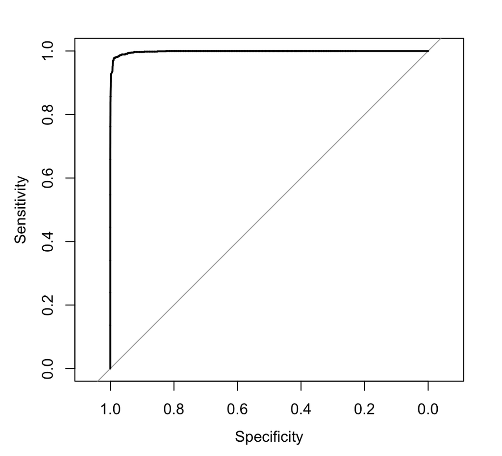

```r
plot(my_roc_glm)
```

```r
#performance values
auc.glm <- auc(my_roc_glm)
coords(my_roc_glm,'best',ret = 'threshold')
```

```
#>    threshold
#> 1 0.05892172
```

```r
coords(my_roc_glm,'best', ret = 'accuracy')
```

```
#>            accuracy
#> threshold 0.9888678
```

```r
coords(my_roc_glm,'best', ret = 'tpr')
```

```
#>                 tpr
#> threshold 0.9772502
```

```r
coords(my_roc_glm,'best', ret = 'fpr')
```

```
#>                  fpr
#> threshold 0.01074847
```

```r
coords(my_roc_glm,'best', ret = 'precision')
```

```
#>           precision
#> threshold 0.7501898
```

## 3.3 LDA

```r
lda.fits <- lda(BlueTarp ~ Red + Green + Blue, family = 'binomial', data=data)

#crossval
set.seed(105)
ctrl <- trainControl(method='cv',
                     number=10,
                     savePredictions = T)
ldamod <- train(BlueTarp~ .-Class,
                data=train,
                method='lda',
                trControl=ctrl)
ldamod$results
```

```
#>   parameter  Accuracy     Kappa  AccuracySD    KappaSD
#> 1      none 0.9831441 0.7421268 0.002124413 0.02897641
```

```r
#predict
lda.predict <- predict(lda.fits, newdata = test, family = 'binomial')

#confusionMatrix
confusionMatrix(data = lda.predict$class, reference = test$BlueTarp)
```

```
#> Confusion Matrix and Statistics
#>
#>           Reference
#> Prediction FALSE  TRUE
#>      FALSE 30319   193
#>      TRUE    290   818
#>
#>                Accuracy : 0.9847
#>                  95% CI : (0.9833, 0.986)
#>     No Information Rate : 0.968
#>     P-Value [Acc > NIR] : < 2.2e-16
#>
#>                   Kappa : 0.7642
#>
#>  Mcnemar's Test P-Value : 1.253e-05
#>
#>             Sensitivity : 0.9905
#>             Specificity : 0.8091
#>          Pos Pred Value : 0.9937
#>          Neg Pred Value : 0.7383
#>              Prevalence : 0.9680
#>          Detection Rate : 0.9589
#>    Detection Prevalence : 0.9650
#>       Balanced Accuracy : 0.8998
#>
#>        'Positive' Class : FALSE
#>
```

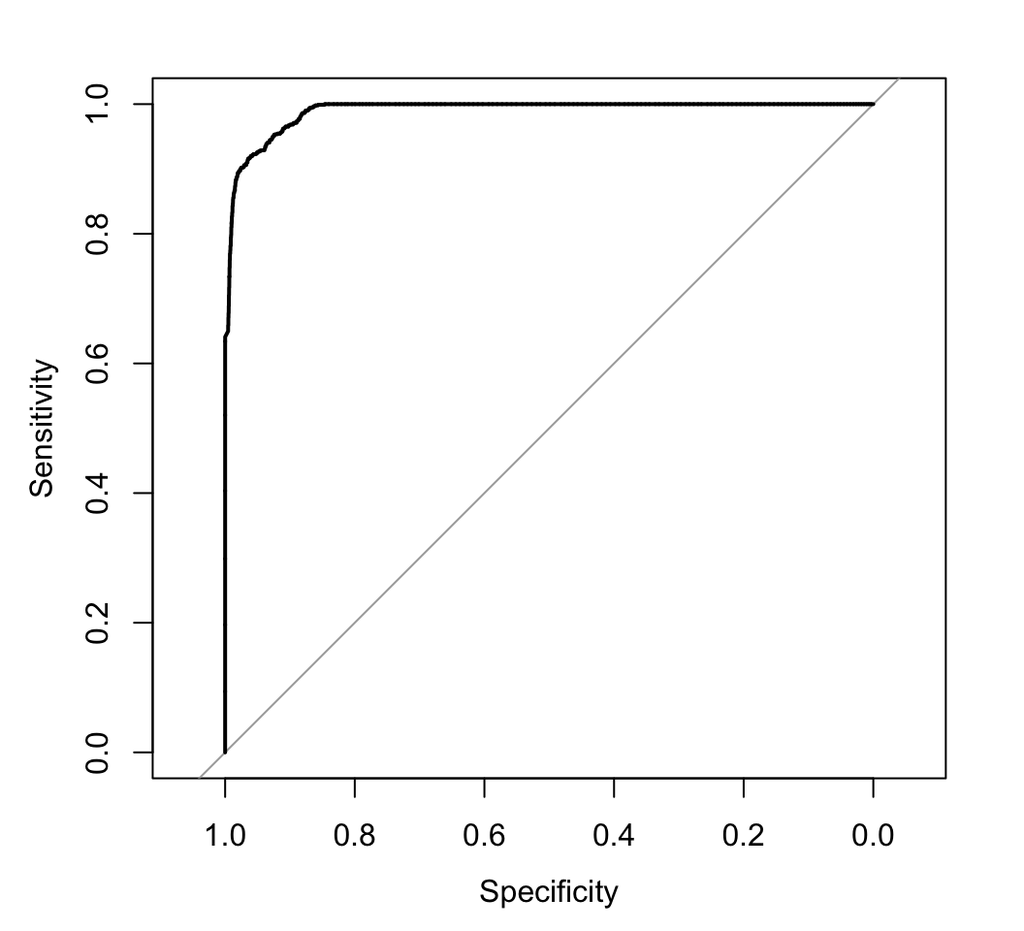

```r
#roc curve
#proc
my_roc_lda <- roc(test$BlueTarp,lda.predict$x)
plot(my_roc_lda)
```

```r
#performance table values
auc(my_roc_lda)
```

```
#> Area under the curve: 0.9897
```

```r
coords(my_roc_lda,'best', ret = 'threshold')
```

```
#>   threshold
#> 1    1.6862
```

```r
coords(my_roc_lda,'best', ret = 'accuracy')
```

```
#>            accuracy
#> threshold 0.9630614
```

```r
coords(my_roc_lda,'best', ret = 'tpr')
```

```
#>                 tpr
#> threshold 0.9159248
```

```r
coords(my_roc_lda,'best', ret = 'fpr')
```

```
#>                  fpr
#> threshold 0.03538175
```

```r
coords(my_roc_lda,'best', ret = 'precision')
```

```
#>           precision
#> threshold 0.4609258
```

## 3.4 QDA

```r
qda.fits <- qda(BlueTarp ~ Red + Green +Blue, family = 'binomial', data=data)

#crossval
set.seed(106)
ctrl <- trainControl(method='cv',
                     number=10,
                     savePredictions = T)
qdamod <- train(BlueTarp~ .-Class,
                data=train,
                method='qda',
                trControl=ctrl)
qdamod$results
```

```
#>   parameter  Accuracy     Kappa  AccuracySD    KappaSD
#> 1      none 0.9942127 0.8976041 0.001874326 0.03559099
```

```r
#predict
qda.predict <- predict(qda.fits, newdata = test, family = 'binomial')

#confusion matrix
confusionMatrix(reference = test$BlueTarp, data = qda.predict$class)
```

```
#> Confusion Matrix and Statistics
#>
#>           Reference
#> Prediction FALSE  TRUE
#>      FALSE 30600   150
#>      TRUE      9   861
#>
#>                Accuracy : 0.995
#>                  95% CI : (0.9941, 0.9957)
#>     No Information Rate : 0.968
#>     P-Value [Acc > NIR] : < 2.2e-16
#>
#>                   Kappa : 0.9129
#>
#>  Mcnemar's Test P-Value : < 2.2e-16
#>
#>             Sensitivity : 0.9997
#>             Specificity : 0.8516
#>          Pos Pred Value : 0.9951
#>          Neg Pred Value : 0.9897
#>              Prevalence : 0.9680
#>          Detection Rate : 0.9677
#>    Detection Prevalence : 0.9725
#>       Balanced Accuracy : 0.9257
#>
#>        'Positive' Class : FALSE
#>
```

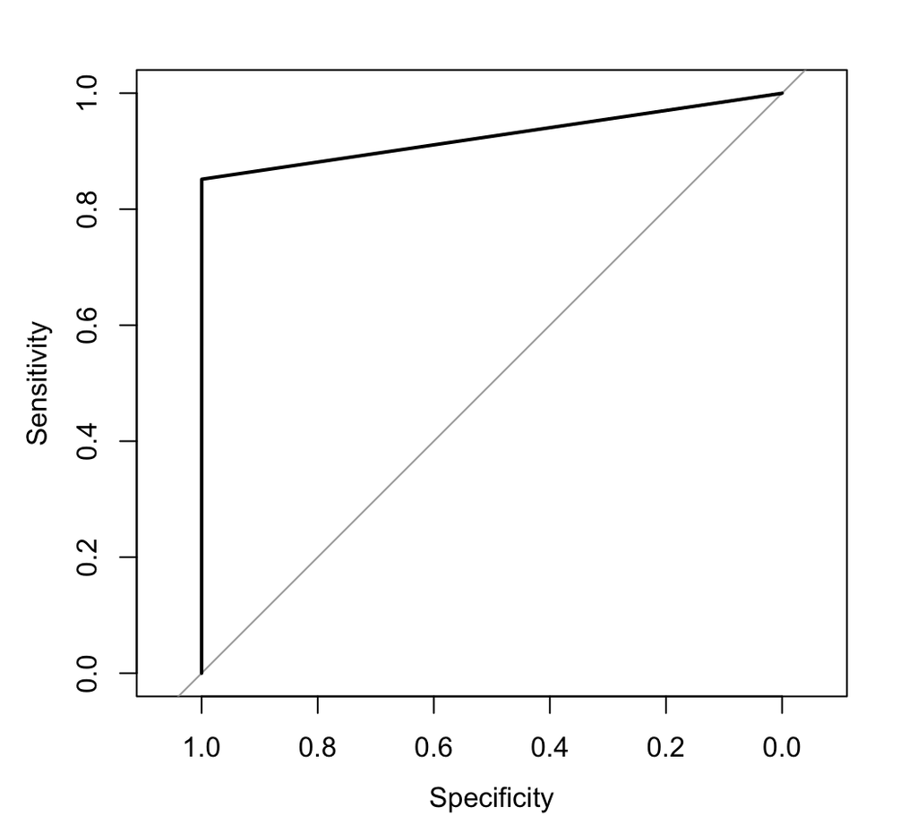

```r
#roc curve
#proc
my_roc_qda <- roc(test$BlueTarp,as.numeric(qda.predict$class))
plot(my_roc_qda)
```

```r
#performance table values
auc(my_roc_qda)
```

```
#> Area under the curve: 0.9257
```

```r
coords(my_roc_qda,'best',ret = 'threshold')
```

```
#>   threshold
#> 1       1.5
```

```r
coords(my_roc_qda,'best', ret = 'accuracy')
```

```
#>            accuracy
#> threshold 0.9949715
```

```r
coords(my_roc_qda,'best', ret = 'tpr')
```

```
#>                tpr
#> threshold 0.851632
```

```r
coords(my_roc_qda,'best', ret = 'fpr')
```

```
#>                    fpr
#> threshold 0.0002940312
```

```r
coords(my_roc_qda,'best', ret = 'precision')
```

```
#>           precision
#> threshold 0.9896552
```

## 3.5 KNN

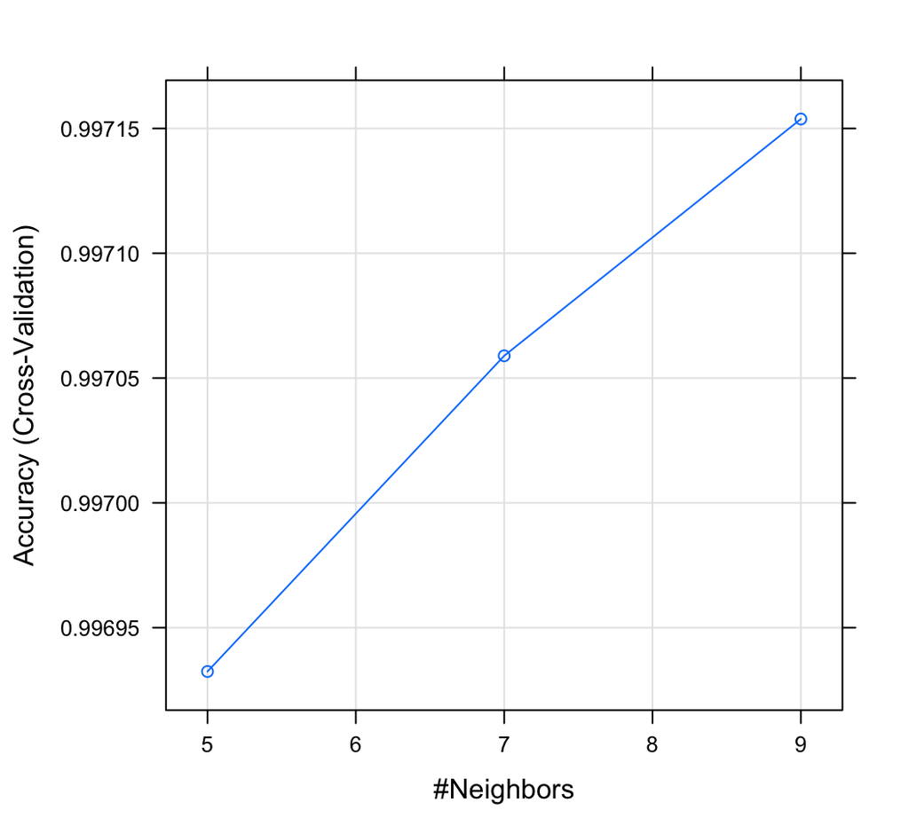

```r
knn.fits <- knn3(BlueTarp ~ Red + Green +Blue,data = data)

#cross val
ctrl <- trainControl(method = 'cv', number = 10, savePredictions = T)
knnmod <- train(BlueTarp~ Red + Green + Blue, method = 'knn', data = train, trControl = ctrl)
plot(knnmod)
```

```r
#best k val
knnBestTune <- knnmod$bestTune

knn.fits.besttune <- knn3(BlueTarp ~ Red + Green +Blue,data = train, k = knnBestTune)

#predict
knn.predict <- predict(knn.fits.besttune, newdata = test, type = 'class')


#confusion matrix
confusionMatrix(table(predicted = knn.predict,
                      reference = test$BlueTarp))
```

```
#> Confusion Matrix and Statistics
#>
#>          reference
#> predicted FALSE  TRUE
#>     FALSE 30551    45
#>     TRUE     58   966
#>
#>                Accuracy : 0.9967
#>                  95% CI : (0.9961, 0.9973)
#>     No Information Rate : 0.968
#>     P-Value [Acc > NIR] : <2e-16
#>
#>                   Kappa : 0.9477
#>
#>  Mcnemar's Test P-Value : 0.237
#>
#>             Sensitivity : 0.9981
#>             Specificity : 0.9555
#>          Pos Pred Value : 0.9985
#>          Neg Pred Value : 0.9434
#>              Prevalence : 0.9680
#>          Detection Rate : 0.9662
#>    Detection Prevalence : 0.9676
#>       Balanced Accuracy : 0.9768
#>
#>        'Positive' Class : FALSE
#>
```

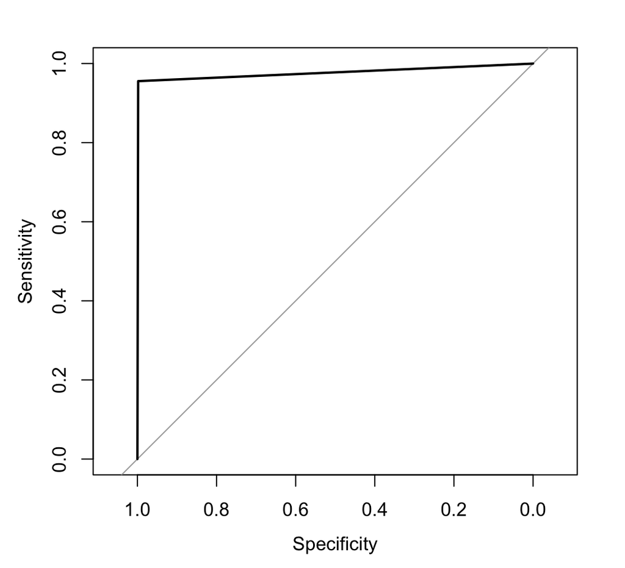

```r
#roc curve
#proc
my_roc_knn <- roc(test$BlueTarp,as.numeric(knn.predict))
plot(my_roc_knn)
```

```r
#performance table values
auc(my_roc_knn)
```

```
#> Area under the curve: 0.9768
```

```r
coords(my_roc_knn,'best',ret = 'threshold')
```

```
#>   threshold
#> 1       1.5
```

```r
coords(my_roc_knn,'best', ret = 'accuracy')
```

```
#>            accuracy
#> threshold 0.9967426
```

```r
coords(my_roc_knn,'best', ret = 'tpr')
```

```
#>                 tpr
#> threshold 0.9554896
```

```r
coords(my_roc_knn,'best', ret = 'fpr')
```

```
#>                   fpr
#> threshold 0.001894868
```

```r
coords(my_roc_knn,'best', ret = 'precision')
```

```
#>           precision
#> threshold 0.9433594
```

## 3.6 Penalized Logistic Regression (ElasticNet)

```r
#Elastic net
fmla <- lm(formula(BlueTarp~.-Class),
             data=train)
#design matrix
x=model.matrix(fmla, data = train)[,-1]
y= train$BlueTarp

#crossval
set.seed(123)
model.elastic <- train(
  BlueTarp ~ Red + Green +Blue, data = train, method = 'glmnet', trControl = trainControl('cv', number = 10), tuneLength = 10
)
#best Tuning value
model.elastic$bestTune
```

```
#>    alpha       lambda
#> 81   0.9 1.901767e-05
```

```r
coef(model.elastic$finalModel, model.elastic$bestTune$lambda)
```

```
#> 4 x 1 sparse Matrix of class "dgCMatrix"
#>                      1
#> (Intercept) -0.3946678
#> Red         -0.2320374
#> Green       -0.1620448
#> Blue         0.3908594
```

```r
#test
test.elastic <- model.matrix(fmla, data=test)[,-1]
predictions.elastic <- predict(model.elastic,newdata = test)

#confusion matrix
confusionMatrix(table(predicted = predictions.elastic,
                      reference = test$BlueTarp))
```

```
#> Confusion Matrix and Statistics
#>
#>          reference
#> predicted FALSE  TRUE
#>     FALSE 30582   120
#>     TRUE     27   891
#>
#>                Accuracy : 0.9954
#>                  95% CI : (0.9945, 0.9961)
#>     No Information Rate : 0.968
#>     P-Value [Acc > NIR] : < 2.2e-16
#>
#>                   Kappa : 0.9214
#>
#>  Mcnemar's Test P-Value : 3.248e-14
#>
#>             Sensitivity : 0.9991
#>             Specificity : 0.8813
#>          Pos Pred Value : 0.9961
#>          Neg Pred Value : 0.9706
#>              Prevalence : 0.9680
#>          Detection Rate : 0.9672
#>    Detection Prevalence : 0.9710
#>       Balanced Accuracy : 0.9402
#>
#>        'Positive' Class : FALSE
#>
```

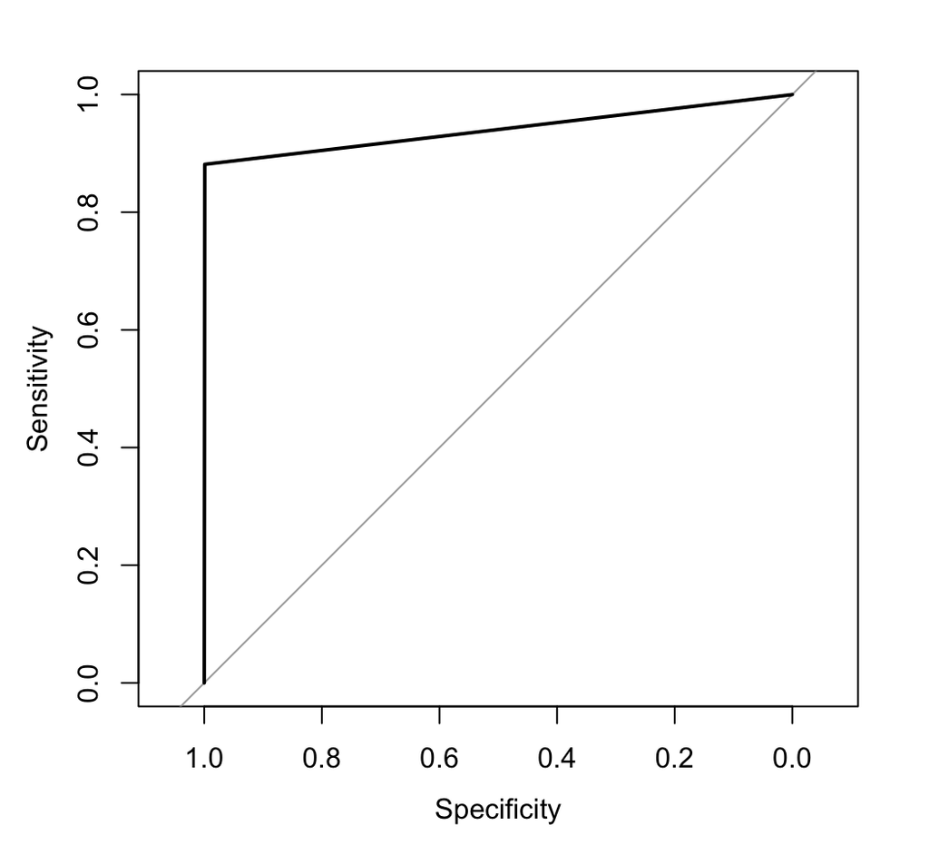

```r
#roc curve
#proc
my_roc_elastic <- roc(test$BlueTarp,as.numeric(predictions.elastic))
plot(my_roc_elastic)
```

```r
#performance table values
auc(my_roc_elastic)
```

```
#> Area under the curve: 0.9402
```

```r
coords(my_roc_elastic,'best',ret = 'threshold')
```

```
#>   threshold
#> 1       1.5
```

```r
coords(my_roc_elastic,'best', ret = 'accuracy')
```

```
#>           accuracy
#> threshold 0.995351
```

```r
coords(my_roc_elastic,'best', ret = 'tpr')
```

```
#>                 tpr
#> threshold 0.8813056
```

```r
coords(my_roc_elastic,'best', ret = 'fpr')
```

```
#>                    fpr
#> threshold 0.0008820935
```

```r
coords(my_roc_elastic,'best', ret = 'precision')
```

```
#>           precision
#> threshold 0.9705882
```

## 3.7 Threshold Selection

# 4 Results (Cross-Validation)

```r
#glm
list.glm <- list('n/a', as.numeric(my_roc_glm$auc),as.numeric(coords(my_roc_glm,'best',ret = 'threshold')),as.numeric(coords(my_roc_glm,'best', ret = 'accuracy')),as.numeric(coords(my_roc_glm,'best', ret = 'tpr')),as.numeric(coords(my_roc_glm,'best', ret = 'fpr')),as.numeric(coords(my_roc_glm,'best', ret = 'precision')))
df_glm <- as.data.frame(list.glm)
df_glm <- data.frame(df_glm, row.names = 'Log Reg')
colnames(df_glm) <- c('Tuning','AUROC','Threshold','Accuracy','TPR','FPR',  'Precision')
df_glm
```

```
#>         Tuning     AUROC  Threshold  Accuracy       TPR        FPR Precision
#> Log Reg    n/a 0.9983467 0.05892172 0.9888678 0.9772502 0.01074847 0.7501898
```

```r
#lda
list.lda <- list(list('n/a', as.numeric(my_roc_lda$auc),as.numeric(coords(my_roc_lda,'best',ret = 'threshold')),as.numeric(coords(my_roc_lda,'best', ret = 'accuracy')),as.numeric(coords(my_roc_lda,'best', ret = 'tpr')),as.numeric(coords(my_roc_lda,'best', ret = 'fpr')),as.numeric(coords(my_roc_lda,'best', ret = 'precision'))))

df_lda <- as.data.frame(list.lda)
df_lda <- data.frame(df_lda,row.names = 'LDA')
colnames(df_lda) <- c('Tuning','AUROC','Threshold','Accuracy','TPR','FPR',  'Precision')
df_lda
```

```
#>     Tuning     AUROC Threshold  Accuracy       TPR        FPR Precision
#> LDA    n/a 0.9897162    1.6862 0.9630614 0.9159248 0.03538175 0.4609258
```

```r
#qda

list.qda <- list(list('n/a', as.numeric(my_roc_qda$auc),as.numeric(coords(my_roc_qda,'best',ret = 'threshold')),as.numeric(coords(my_roc_qda,'best', ret = 'accuracy')),as.numeric(coords(my_roc_qda,'best', ret = 'tpr')),as.numeric(coords(my_roc_qda,'best', ret = 'fpr')),as.numeric(coords(my_roc_qda,'best', ret = 'precision'))))

df_qda <- as.data.frame(list.qda)
df_qda <- data.frame(df_qda,row.names = 'QDA')
colnames(df_qda) <- c('Tuning','AUROC','Threshold','Accuracy','TPR','FPR',  'Precision')
df_qda
```

```
#>     Tuning    AUROC Threshold  Accuracy      TPR          FPR Precision
#> QDA    n/a 0.925669       1.5 0.9949715 0.851632 0.0002940312 0.9896552
```

```r
#knn
list.knn <- list(list(as.numeric(knnBestTune), as.numeric(my_roc_knn$auc),as.numeric(coords(my_roc_knn,'best',ret = 'threshold')),as.numeric(coords(my_roc_knn,'best', ret = 'accuracy')),as.numeric(coords(my_roc_knn,'best', ret = 'tpr')),as.numeric(coords(my_roc_knn,'best', ret = 'fpr')),as.numeric(coords(my_roc_knn,'best', ret = 'precision'))))

df_knn <- as.data.frame(list.knn)
df_knn <- data.frame(df_knn,row.names = 'KNN')
colnames(df_knn) <- c('Tuning','AUROC','Threshold','Accuracy','TPR','FPR',  'Precision')
df_knn
```

```
#>     Tuning     AUROC Threshold  Accuracy       TPR         FPR Precision
#> KNN      9 0.9767974       1.5 0.9967426 0.9554896 0.001894868 0.9433594
```

```r
#elastic

list.elastic <- list(list(model.elastic$bestTune$lambda, as.numeric(my_roc_elastic$auc),as.numeric(coords(my_roc_elastic,'best',ret = 'threshold')),as.numeric(coords(my_roc_elastic,'best', ret = 'accuracy')),as.numeric(coords(my_roc_elastic,'best', ret = 'tpr')),as.numeric(coords(my_roc_elastic,'best', ret = 'fpr')),as.numeric(coords(my_roc_elastic,'best', ret = 'precision'))))

df_elastic <- as.data.frame(list.elastic)
df_elastic <- data.frame(df_elastic,row.names = 'Penalized Log Reg')
colnames(df_elastic) <- c('Tuning','AUROC','Threshold','Accuracy','TPR','FPR',  'Precision')
df_elastic
```

```
#>                         Tuning     AUROC Threshold Accuracy       TPR
#> Penalized Log Reg 1.901767e-05 0.9402118       1.5 0.995351 0.8813056
#>                            FPR Precision
#> Penalized Log Reg 0.0008820935 0.9705882
```

```r
#Perf Table

PerfTable <- rbind(df_glm,df_lda,df_qda,df_knn,df_elastic)
colnames(PerfTable) <- c('Tuning','AUROC','Threshold','Accuracy','TPR','FPR',   'Precision')

PerfTable
```

```
#>                                 Tuning     AUROC  Threshold  Accuracy       TPR
#> Log Reg                            n/a 0.9983467 0.05892172 0.9888678 0.9772502
#> LDA                                n/a 0.9897162 1.68619989 0.9630614 0.9159248
#> QDA                                n/a 0.9256690 1.50000000 0.9949715 0.8516320
#> KNN                                  9 0.9767974 1.50000000 0.9967426 0.9554896
#> Penalized Log Reg 1.90176708411387e-05 0.9402118 1.50000000 0.9953510 0.8813056
#>                            FPR Precision
#> Log Reg           0.0107484727 0.7501898
#> LDA               0.0353817505 0.4609258
#> QDA               0.0002940312 0.9896552
#> KNN               0.0018948675 0.9433594
#> Penalized Log Reg 0.0008820935 0.9705882
```

# 5 Conclusions

### 5.0.1 Conclusion #1

After engineering and testing all the models, I have concluded that the KNN approach proved to have the best results. We were able to successfully predict Blue Tarps at a 99.7% accuracy.We calculated this accuracy by creating a confusion matrix which shows how our model predicted on the test data set and compared it to the actual values.

### 5.0.2 Conclusion #2

After evaluating all the models, I concluded that KNN provided the best results but we also found other models that performed well. QDA and Elastic net had accuracy slightly lower than KNN but were more precise than KNN. I chose KNN over QDA and Elastic net because we were prioritizing accuracy in this simulation.

### 5.0.3 Conclusion #3

I think the approach that I took would help save lives by being able to accurately predict where the displaced individuals are. All the models tested very well and tested very accurately. Being able to predict efficiently and accurately in this kind of situation is very important and the models I tested and ended up choosing to predict where the Blue Tents were showed these characteristics.

### 5.0.4 Conclusion #4

One thing that I could do different that may improve results is to use a multinomial approach instead of binomial. I set my factor to a Boolean. It was either Blue Tarp or not Blue Tarp, even though the original data set had more than just Blue Tarp as a category. I think that this may help improve the overall prediction since it would be more represntative of the real world. I think that the multinomial appraoch would work better than binomial.

# 6 Hold-out Data / EDA

# 7 Results (Hold-Out)

# 8 Final Conclusions

### 8.0.1 Conclusion #1

### 8.0.2 Conclusion #2

### 8.0.3 Conclusion #3

### 8.0.4 Conclusion #4

### 8.0.5 Conclusion #5

### 8.0.6 Conclusion #6